# Precision Analysis

hiox-tech

2026-08-06

# 1 Analysis Objectives

Precision evaluates the degree of agreement among results measured on the same sample by the same measurement system under repeatable conditions, usually expressed as the standard deviation (SD) or coefficient of variation (CV%). CLSI EP05 subdivides precision into variance components by condition, such as within-run, between-run, and between-day, and provides estimates, confidence intervals, and acceptance limits for judging each component.

```r
library(ivdtools)
library(readr)
```

> **Data format requirement:** `precision()` ultimately calls `VCA::anovaVCA()`, which requires a plain `data.frame`. Since `readr::read_csv()` reads in a tibble, this document consistently converts to a `data.frame` first, then converts the experimental factor columns (day, run, replicate, etc.) to factors.

# 2 Overview of Functions

| Function | Main purpose | Key input or output |
| --- | --- | --- |
| `precision()` | Create a precision variance-component analysis object | Nested formula, `by` grouping, balance check |
| `outlier()` | Per-sample outlier detection | Grubbs or IQR method |
| `normal()` | Per-sample normality test | Shapiro-Wilk etc., `level` controls the confidence level |
| `variance()` / `vc()` | Estimate variance components | VC, %Total, SD, CV%, `NegVC` passed here |
| `ci()` | Confidence intervals for SD/CV of each component | Satterthwaite approximation |
| `profile()` | Sadler precision profile fitting | 10 candidate models, AIC selection |
| `list_sadler()` | View the 10 Sadler models | Model formula and type |
| `summary()` / `plot()` | Summarize and plot | `plot(type=...)` selects the graphic |

After `precision()` creates the object, analysis results accumulate into the object step by step through `outlier()`, `normal()`, `variance()`, `ci()`, and `profile()`, and **must be reassigned**:

```
precision() -> outlier() -> normal() -> variance() -> ci() -> profile()
```

Only analyses that have been executed appear in `summary()`, and some `plot()` graphics depend on prior analyses.

# 3 Example 1: EP05 20×2×2 Single-Sample Precision

## 3.1 Reading and Validating Data

20×2×2 means 20 days, 2 runs per day, and 2 replicates per run, for a total of 80 results; it is one of the classic EP05 designs:

```r
ep05 <- read_csv("./data/precision-ep05.csv", show_col_types = FALSE)
ep05 <- as.data.frame(ep05)
str(ep05)
```

```
#> 'data.frame':    80 obs. of  4 variables:
#>  $ day  : num  1 1 1 1 2 2 2 2 3 3 ...
#>  $ run  : num  1 1 2 2 1 1 2 2 1 1 ...
#>  $ rep  : num  1 2 1 2 1 2 1 2 1 2 ...
#>  $ value: num  96.9 93.5 99.3 101.5 103 ...
```

The experimental factor columns are integers in the CSV and are converted to factors after reading:

```r
ep05$day <- factor(ep05$day)
ep05$run <- factor(ep05$run)
ep05$rep <- factor(ep05$rep)
```

```r
dim(ep05)
```

```
#> [1] 80  4
```

```r
summary(ep05$value)
```

```
#>    Min. 1st Qu.  Median    Mean 3rd Qu.    Max.
#>   86.06   94.83   99.33   99.11  103.53  115.01
```

`value ~ day/run` means the variance components are nested layer by layer as between-day (day) -> within-day run (run). `/` is the nesting notation, equivalent to treating each deeper factor as a factor nested within the factor above it.

## 3.2 Creating the Analysis Object and Pre-Check

```r
p <- precision(ep05, value ~ day/run)
p
```

```
#> Precision analysis object
#>   Data class          : data.frame
#>   Total rows          : 80
#>   Formula             : value ~ day/run
#>   Samples             : 1
#>
#> Factor levels
#>   day         : 1 (4), 2 (4), 3 (4), 4 (4), 5 (4), 6 (4), 7 (4), 8 (4), 9 (4), 10 (4), 11 (4), 12 (4), 13 (4), 14 (4), 15 (4), 16 (4), 17 (4), 18 (4), 19 (4), 20 (4)
#>   run         : 1 (40), 2 (40)
#>   rep         : 1 (40), 2 (40)
#>
#> Analysis status
#>
#>   [ ] outlier
#>   [ ] normal
#>   [ ] variance
#>   [ ] ci
#>   [ ] profile
```

Perform per-sample outlier detection and normality testing:

```r
p <- outlier(p, method = "grubbs")
```

```
#> Outlier detection -- Grubbs (alpha = 0.05)
#>   No outliers detected.
```

```r
p <- normal(p, method = "shapiro")
```

```
#> Normality test -- Shapiro-Wilk
#>   Sample               n           W  p-value
#>   ---------------------------------------------
#>   all                 80      0.9868  0.5858
```

> **Parameter notes:** The `method` of `outlier()` can be `"grubbs"` (default) or `"iqr"`, and `alpha` is the Grubbs significance level. For `normal()`, `method="auto"` selects the test based on sample size (Shapiro-Wilk for n≤50, Anderson-Darling for larger samples); when `method="shapiro"` is specified, the reported `W` column is the true Shapiro-Wilk W statistic. For single-sample data with n=80, either approach is acceptable; this example specifies it explicitly for illustration.

## 3.3 Variance Components and Confidence Intervals

```r
p <- variance(p)
```

```
#> Variance components
#>  sample component      VC %Total     SD  CV[%]
#> ----------------------------------------------
#>     all       day 18.8358   42.6 4.3400 4.3788
#>     all   day:run 17.4343   39.4 4.1754 4.2128
#>     all     error  7.9482   18.0 2.8193 2.8445
```

The `NegVC` parameter needs to be passed at `variance()`:

```r
p <- variance(p, NegVC = TRUE)   # allow negative variance components (default FALSE)
```

```r
p <- ci(p)
```

```
#> Confidence intervals (SD)
#>  sample component estimate  lower  upper
#> ----------------------------------------
#>     all     total   6.6497 5.4288 8.5842
#>     all       day   4.3400 0.0000 6.2255
#>     all   day:run   4.1754 2.0129 5.5513
#>     all     error   2.8193 2.3147 3.6073
#>
#> Confidence intervals (%CV)
#>  sample component estimate  lower  upper
#> ----------------------------------------
#>     all     total   6.7091 5.4773 8.6609
#>     all       day   4.3788 0.0000 6.2812
#>     all   day:run   4.2128 2.0309 5.6009
#>     all     error   2.8445 2.3353 3.6395
```

`ci()` uses the Satterthwaite effective-degrees-of-freedom approximation to compute confidence intervals for the SD and CV of each component.

## 3.5 Graphics

A scatter plot can be used to quickly identify test anomalies and the distribution of measurements:

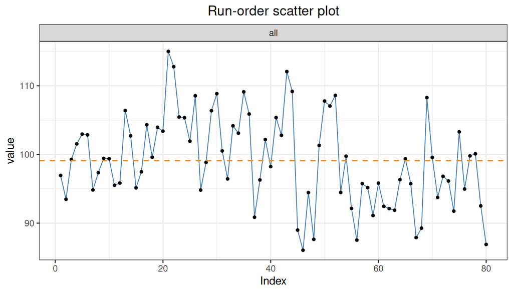

```r
plot(p, type = "dot")
```

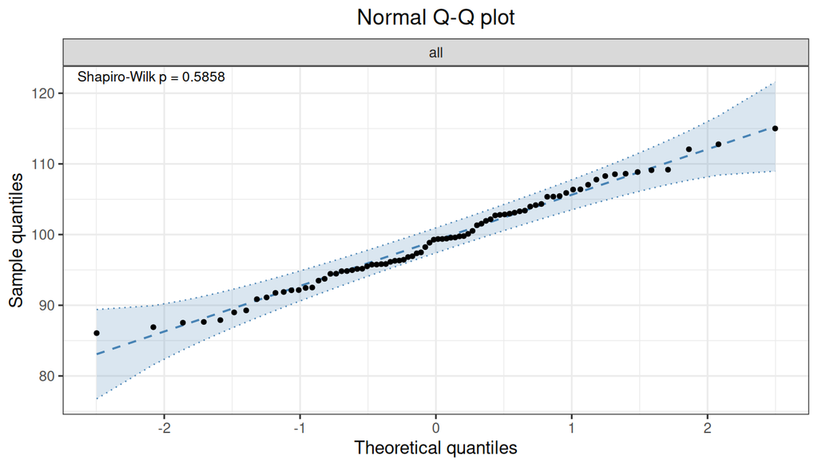

```r
plot(p, type = "qq")
```

> **Graphic dependencies:** `plot(type="dot")` is a scatter plot by run order (no prior analysis needed), `type="his"` is a standard histogram; `type="var"` requires `variance()` to have been run, `type="qq"` requires `normal()`, and `type="profile"` requires `profile()`. Confirm that the corresponding analysis has been run before plotting.

```r
summary(p)
```

```
#>
#> Precision analysis -- summary
#> ----------------------------------------
#>
#> Precision analysis object
#>   Data class          : data.frame
#>   Total rows          : 80
#>   Formula             : value ~ day/run
#>   Samples             : 1
#>
#> Factor levels
#>   day         : 1 (4), 2 (4), 3 (4), 4 (4), 5 (4), 6 (4), 7 (4), 8 (4), 9 (4), 10 (4), 11 (4), 12 (4), 13 (4), 14 (4), 15 (4), 16 (4), 17 (4), 18 (4), 19 (4), 20 (4)
#>   run         : 1 (40), 2 (40)
#>   rep         : 1 (40), 2 (40)
#>
#> Analysis status
#>
#>   [x] outlier
#>   [x] normal
#>   [x] variance
#>   [x] ci
#>   [ ] profile
#>
#> Outlier detection -- Grubbs (alpha = 0.05)
#>   No outliers detected.
#>
#> Normality test -- Shapiro-Wilk
#>   Sample               n           W  p-value
#>   ---------------------------------------------
#>   all                 80      0.9868  0.5858
#>
#> Variance components
#>  sample component      VC %Total     SD  CV[%]
#> ----------------------------------------------
#>     all       day 18.8358   42.6 4.3400 4.3788
#>     all   day:run 17.4343   39.4 4.1754 4.2128
#>     all     error  7.9482   18.0 2.8193 2.8445
#>
#> Confidence intervals (SD)
#>  sample component estimate  lower  upper
#> ----------------------------------------
#>     all     total   6.6497 5.4288 8.5842
#>     all       day   4.3400 0.0000 6.2255
#>     all   day:run   4.1754 2.0129 5.5513
#>     all     error   2.8193 2.3147 3.6073
#>
#> Confidence intervals (%CV)
#>  sample component estimate  lower  upper
#> ----------------------------------------
#>     all     total   6.7091 5.4773 8.6609
#>     all       day   4.3788 0.0000 6.2812
#>     all   day:run   4.2128 2.0309 5.6009
#>     all     error   2.8445 2.3353 3.6395
```

# 4 Example 2: Multi-Sample 3×5 and Sadler Profile

## 4.1 Reading Data

When multiple concentration levels need to be evaluated, use `by` to specify the sample grouping column, and estimate the variance components separately for each sample:

```r
profile_data <- as.data.frame(read_csv(
  "./data/precision-profile.csv",
  show_col_types = FALSE
))
profile_data$sample <- factor(profile_data$sample)
profile_data$day <- factor(profile_data$day)
profile_data$rep <- factor(profile_data$rep)
```

## 4.2 Per-Sample Variance Components

```r
p2 <- precision(profile_data, value ~ day, by = "sample")
p2 <- variance(p2)
```

```
#> Variance components
#>  sample component       VC %Total      SD  CV[%]
#> ------------------------------------------------
#>      L1       day   0.6376   63.0  0.7985 3.9446
#>      L1     error   0.3750   37.0  0.6124 3.0250
#>      L2       day   5.7139   75.1  2.3904 4.7584
#>      L2     error   1.8937   24.9  1.3761 2.7393
#>      L3       day   3.3913   15.7  1.8415 1.8088
#>      L3     error  18.1466   84.3  4.2599 4.1840
#>      L4       day  30.5549   54.6  5.5276 2.7529
#>      L4     error  25.4525   45.4  5.0451 2.5126
#>      L5       day   0.0000    0.0  0.0000 0.0000
#>      L5     error 171.7986  100.0 13.1072 3.3003
```

```r
p2 <- ci(p2)
```

```
#> Confidence intervals (SD)
#>  sample component estimate  lower   upper
#> -----------------------------------------
#>      L1     total   1.0063 0.6007  2.9368
#>      L1       day   0.7985 0.0000  1.4267
#>      L1     error   0.6124 0.4391  1.0108
#>      L2     total   2.7582 1.5714  9.9889
#>      L2       day   2.3904 0.0000  4.2023
#>      L2     error   1.3761 0.9868  2.2716
#>      L3     total   4.6409 3.2872  7.8819
#>      L3       day   1.8415 0.0000  4.1779
#>      L3     error   4.2599 3.0547  7.0319
#>      L4     total   7.4838 4.6166 19.1652
#>      L4       day   5.5276 0.0000 10.0268
#>      L4     error   5.0451 3.6177  8.3280
#>      L5     total  13.1072 9.5629 20.8255
#>      L5       day   0.0000     NA      NA
#>      L5     error  13.1072 9.3990 21.6365
#>
#> Confidence intervals (%CV)
#>  sample component estimate  lower   upper
#> -----------------------------------------
#>      L1     total   4.9710 2.9673 14.5079
#>      L1       day   3.9446 0.0000  7.0480
#>      L1     error   3.0250 2.1692  4.9936
#>      L2     total   5.4905 3.1281 19.8843
#>      L2       day   4.7584 0.0000  8.3652
#>      L2     error   2.7393 1.9643  4.5219
#>      L3     total   4.5583 3.2287  7.7416
#>      L3       day   1.8088 0.0000  4.1035
#>      L3     error   4.1840 3.0003  6.9067
#>      L4     total   3.7271 2.2992  9.5447
#>      L4       day   2.7529 0.0000  4.9936
#>      L4     error   2.5126 1.8017  4.1476
#>      L5     total   3.3003 2.4078  5.2436
#>      L5       day   0.0000     NA      NA
#>      L5     error   3.3003 2.3666  5.4478
```

Comparing the proportion of variability across samples can be used for product optimization and testing scheme design:

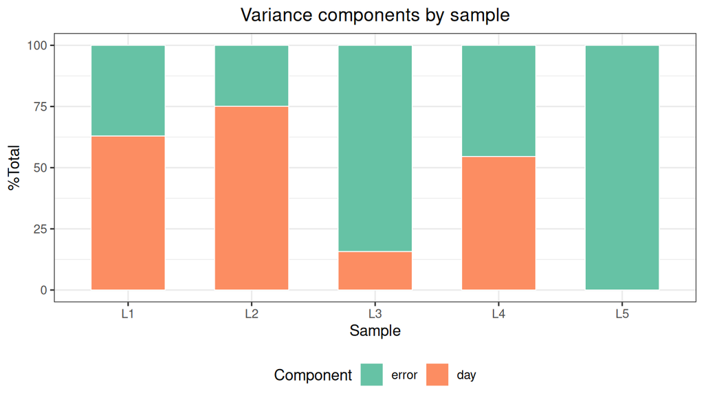

```r
plot(p2, type = "var")
```

## 4.3 Precision Profile

`profile()` fits the Sadler model family to each variance component and selects the best model by AIC:

```r
list_sadler()
```

```
#> Sadler Precision Profile Models
#>
#>    1  Constant SD           sigma^2 = b1
#>    2  Constant CV           sigma^2 = b1 * mu^2
#>    3  Linear (variance)     sigma^2 = b1 + b2 * mu
#>    4  Power (fixed K)       sigma^2 = b1 * mu^K
#>    5  Power (fixed K, +intercept)  sigma^2 = b1 + b2 * mu^K
#>    6  Linear (SD)           sigma = b1 + b2 * mu
#>    7  Power (SD)            sigma = b1 + b2 * mu^b3
#>    8  Power (variance)      sigma^2 = b1 + b2 * mu^b3
#>    9  Exponential (log-log)  log(sigma^2) = b1 + b2 * log(mu)
#>   10  Power (full)          sigma^2 = b1 * mu^b2
```

```r
p2 <- profile(p2, model.no = 1:10)
```

```
#> Precision profiles -- Sadler
#>   total: sigma = 0.0000 + 0.0086 * mu^1.6702  (AIC = 56.45, R^2 = 0.9847)
#>   day: sigma = 0.0000 + 0.0095 * mu^1.4951  (AIC = 43.46, R^2 = 0.8919)
#>   error: sigma^2 = 0.0010 * mu^2  (AIC = 55.96, R^2 = 0.9806)
```

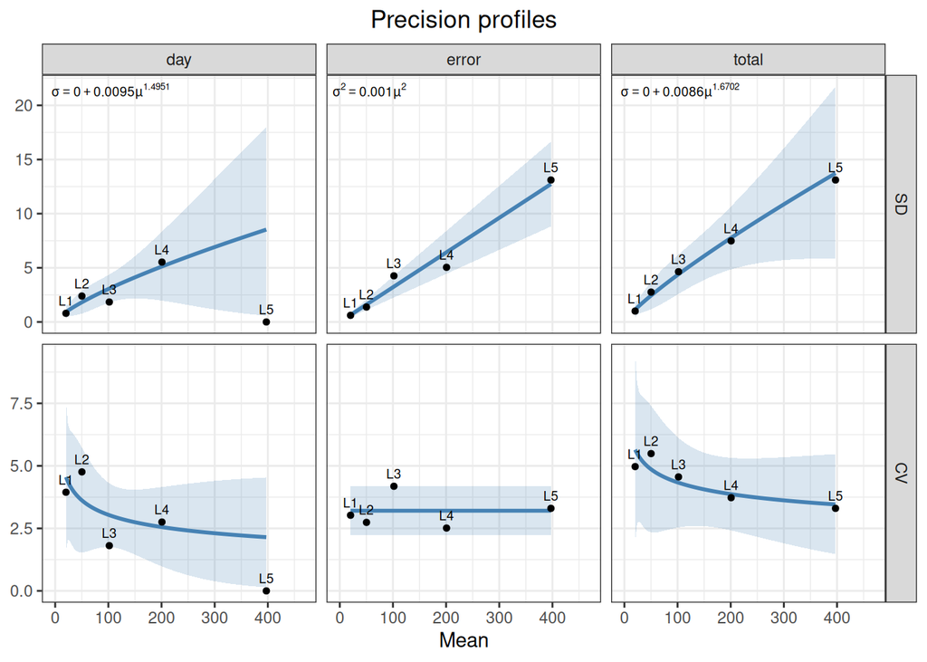

```r
plot(p2, type = "profile")
```

> **Parameter notes:** `profile(model.no = 1:10)` specifies the candidate model numbers; `...` can be passed to the internal Sadler fit (for example `K`). Each variance component requires at least 3 samples with a finite SD to be fitted, so a multi-sample design should include at least 3 concentration levels. The profile can be used, for example, in functional-sensitivity analyses to predict the SD/CV at any concentration (see 《Functional Sensitivity》).

# 5 Example 3: Multi-Sample Multi-Site (Site) Precision

## 5.1 Reading Data

The data contain 2 sites, 3 samples, and per site per sample 3 days × 3 runs × 5 replicates:

```r
sites_data <- as.data.frame(read_csv(
  "./data/precision-sites.csv",
  show_col_types = FALSE
))
sites_data[] <- lapply(sites_data, function(x)
  if (is.numeric(x) && all(x == round(x))) factor(x) else x)
str(sites_data)
```

```
#> 'data.frame':    270 obs. of  6 variables:
#>  $ site  : chr  "A" "A" "A" "A" ...
#>  $ sample: chr  "S1" "S1" "S1" "S1" ...
#>  $ day   : Factor w/ 3 levels "1","2","3": 1 1 1 1 1 1 1 1 1 1 ...
#>  $ run   : Factor w/ 3 levels "1","2","3": 1 1 1 1 1 2 2 2 2 2 ...
#>  $ rep   : Factor w/ 5 levels "1","2","3","4",..: 1 2 3 4 5 1 2 3 4 5 ...
#>  $ value : num  49.2 52.3 48.8 49.4 51.5 ...
```

## 5.2 Multi-Column Grouping

`by` can accept multiple column names and groups internally by the interaction, obtaining all site × sample combinations at once:

```r
p3 <- precision(sites_data, value ~ day/run, by = c("sample", "site"))
p3 <- variance(p3)
```

```
#> Variance components
#>  sample component      VC %Total     SD  CV[%]
#> ----------------------------------------------
#>    S1.A       day  0.0000    0.0 0.0000 0.0000
#>    S1.A   day:run  0.1646    6.8 0.4057 0.8231
#>    S1.A     error  2.2677   93.2 1.5059 3.0553
#>    S2.A       day  0.3241    4.3 0.5693 0.5602
#>    S2.A   day:run  0.1523    2.0 0.3903 0.3840
#>    S2.A     error  7.0483   93.7 2.6549 2.6124
#>    S3.A       day  4.4871   15.6 2.1183 1.0420
#>    S3.A   day:run  1.7006    5.9 1.3041 0.6415
#>    S3.A     error 22.5797   78.5 4.7518 2.3375
#>    S1.B       day  0.0000    0.0 0.0000 0.0000
#>    S1.B   day:run  0.5459   23.5 0.7389 1.4758
#>    S1.B     error  1.7784   76.5 1.3335 2.6637
#>    S2.B       day  0.0000    0.0 0.0000 0.0000
#>    S2.B   day:run  1.6690   21.5 1.2919 1.2891
#>    S2.B     error  6.0856   78.5 2.4669 2.4616
#>    S3.B       day  0.7633    2.3 0.8737 0.4448
#>    S3.B   day:run  0.0000    0.0 0.0000 0.0000
#>    S3.B     error 31.8033   97.7 5.6394 2.8709
```

```r
names(p3$results)
```

```
#> [1] "S1.A" "S2.A" "S3.A" "S1.B" "S2.B" "S3.B"
```

## 5.3 Splitting by Site for Separate Analysis

An equivalent approach is to first `split()` by site and then run the same analysis parameters on each site subset. When the variance-component structure is expected to differ between sites, or separate reports are needed, splitting and analyzing separately is clearer:

```r
for (s in c("A", "B")) {
  sub <- sites_data[sites_data$site == s, ]
  ps <- precision(sub, value ~ day/run, by = "sample")
  ps <- variance(ps)
  ps <- ci(ps)
}
```

> **Note:** Multi-center studies should unify the analysis plan, variance-component model, and reporting convention; when “reporting per center first and then combining”, be sure to record whether each center’s raw data were included, and whether the exclusion criteria and factor definitions are consistent.

# 6 Example 4: Custom More Complex Models

## 6.1 Reading Data

Besides the standard day/run/replicate nesting, the `precision()` formula can be any VCA nested structure, for example adding an operator level: `value ~ operator/day/run`, i.e., nested layer by layer as operator -> day -> run:

```r
custom_data <- as.data.frame(read_csv(
  "./data/precision-custom.csv",
  show_col_types = FALSE
))
custom_data[] <- lapply(custom_data, function(x)
  if (is.numeric(x) && all(x == round(x))) factor(x) else x)
```

## 6.2 Fitting and Interpretation

```r
p4 <- precision(custom_data, value ~ operator/day/run)
p4 <- variance(p4)
```

```
#> Variance components
#>  sample        component     VC %Total     SD  CV[%]
#> ----------------------------------------------------
#>     all         operator 2.2914   11.8 1.5137 1.4898
#>     all     operator:day 6.3159   32.4 2.5132 2.4734
#>     all operator:day:run 3.2463   16.7 1.8017 1.7733
#>     all            error 7.6322   39.2 2.7627 2.7190
```

# 7 Key Points for Interpreting Results

1. **Design match**: First clarify the nesting structure of the study design; the `precision()` formula must faithfully reflect the experimental hierarchy.
2. **Data format**: After `read_csv`, convert to `data.frame` and explicitly convert factor columns to factor to avoid VCA errors or ambiguity.
3. **Call order**: `outlier → normal → variance → ci → profile`, reassign after each analysis; plotting depends on prior analyses.
4. **Negative components**: When a factor has too few levels or the data happen to be nearly identical, a variance component may be set to zero; interpret carefully and specify the handling approach in the protocol.
5. **CI applicability**: The Satterthwaite approximation becomes less accurate with very few variance components or unbalanced data; note the method in the report.
6. **Terminology table**: Rearrange the numeric quantities in `$results` (`sd_comp`/`cv_comp`/`vc`) into an EP05 terminology table; do not directly use the display-oriented string `$vc`.
7. **Acceptability judgment**: Statistical estimates do not automatically constitute a pass/fail determination; they should be compared with pre-specified precision limits and reviewed by professionals.